# Modern concepts and methods in Macroecology and Biogeography

Day 7: Phylogenetic diversity

Patrick Weigelt, Pierre Denelle & Holger Kreft

May 29th, 2024

*back to overview*

**Preparation:** Please open your RStudio project and download the new data (‘Phylogeny_ConservativeCon_Checklist.zip’, ‘palms_specsxsites_phylo.csv’ and ‘palmtree_pruned.nex’) for today from [Stud-IP](https://studip.uni-goettingen.de/dispatch.php/course/files/index/04ed58d2396f403863695c2c87fac20a?cid=9def2280fd13b1ea9b0ae99373749090) and unzip and copy them into your .Rproj folder ‘/Data/’. You can use `getwd()` to locate your current working directory, which should be your project folder. Please install the following R-packages using `install.packages()`:

- `ape`
- `rWCVP`
- `remotes`
- `sf`
- `dplyr`
- `psych`
- `picante`
- `pez`
- `ggplot2`
- `cowplot`
- `GGally`
- `RColorBrewer`

And install `rWCVPdata` using `remotes::install_github('matildabrown/rWCVPdata')`.

If you want to visualize this tutorial in the viewer inside RStudio (to save space on your screen) run the following chunk of code:

```r
install.packages("rstudioapi") # install an R-package required for this step
dir <- tempfile()
dir.create(dir)
download.file("https://gift.uni-goettingen.de/mcmmb/index.html", destfile = file.path(dir, "index.html"))
download.file("https://gift.uni-goettingen.de/mcmmb/Day7.html", destfile = file.path(dir, "Day7.html"))
htmlFile <- file.path(dir, "Day7.html")
rstudioapi::viewer(htmlFile)
```

Now you can conveniently copy code from the viewer into your script.

**Load R packages & island data set**

```r
library(dplyr) # basic data manipulation

library(sf) #  Geospatial fun

library(rWCVP) # Taxonomic standardisation of plant species names
library(rWCVPdata) # According data for standardization
library(ape) # Analyses of phylogenetics and evolution
library(picante) # Phylogenies and ecology
library(pez) # Phylogenies and ecology

library(psych) # basic stats stuff
library(ggplot2) # for plotting
library(cowplot) # for multi-panel plots
library(GGally) # pairs plot
library(RColorBrewer) # fancy colour palettes
```

# 1. Load data into R

## a. Load a phylogeny & look at structure of ‘multiPhylo’ object

**load multi-tree object into R**

Data from Faurby, S., Eiserhardt, W.L., Baker, W.J. & Svenning, J.-C. (2016).  
An all-evidence species-level supertree for the palms (Arecaceae).  
*Molecular Phylogenetics and Evolution*, 100, 57-69.

```r
palmtrees <- read.nexus("data/Phylogeny_ConservativeCon_Checklist.nex")

palmtrees
```

```
## 1000 phylogenetic trees
```

```r
palmtrees[[1]]
```

```
##
## Phylogenetic tree with 2539 tips and 2538 internal nodes.
##
## Tip labels:
##   Nypa_fruticans, Sabal_mauritiiformis, Sabal_pumos, Sabal_domingensis, Sabal_minor, Sabal_palmetto, ...
##
## Rooted; includes branch lengths.
```

```r
palmtree <- palmtrees[[1]]
str(palmtree)
```

```
## List of 4
##  $ edge       : int [1:5076, 1:2] 2540 2541 2541 2542 2543 2544 2545 2546 2546 2547 ...
##  $ edge.length: num [1:5076] 8.89 95.72 9.44 9.78 12.25 ...
##  $ Nnode      : int 2538
##  $ tip.label  : chr [1:2539] "Nypa_fruticans" "Sabal_mauritiiformis" "Sabal_pumos" "Sabal_domingensis" ...
##  - attr(*, "class")= chr "phylo"
##  - attr(*, "order")= chr "cladewise"
```

*Explanation of structure of a phylogeny in R*  
**edge**: a two-column matrix where each row represents a branch (or edge) of the tree. The nodes and the tips are symbolized with integers. The n tips are numbered from 1 to n, and the m (internal) nodes from n+1 to n+m (the root being n + 1). For each row, the first column gives the ancestor.

**edge.length (optional)**: A numeric vector giving the lengths of the branches given by edge.

**tip.label**: A vector of mode character giving the labels of the tips. The order of these labels corresponds to the integers 1 to n in edge.

**Nnode**: An integer value giving the number of nodes in the tree (m).

**node.label** (optional): A vector of mode character giving the labels of the nodes (ordered in the same way as the tip.label).

**root.edge** (optional): A numeric value giving the length of the branch at the root if it exists.

```r
# Number of nodes (m) (n is the number of tips)
palmtree$Nnode
```

```
## [1] 2538
```

```r
# Tip labels
head(palmtree$tip.label)
```

```
## [1] "Nypa_fruticans"       "Sabal_mauritiiformis" "Sabal_pumos"
## [4] "Sabal_domingensis"    "Sabal_minor"          "Sabal_palmetto"
```

```r
length(palmtree$tip.label)
```

```
## [1] 2539
```

```r
# Edges
head(palmtree$edge)
```

```
##      [,1] [,2]
## [1,] 2540 2541
## [2,] 2541    1
## [3,] 2541 2542
## [4,] 2542 2543
## [5,] 2543 2544
## [6,] 2544 2545
```

```r
range(palmtree$edge[, 1]) # ranges from n+1 to n+m (length(palmtree$tip.label) + palmtree$Nnode)
```

```
## [1] 2540 5077
```

```r
is.rooted(palmtree) # does the phylogeny have a root? i.e. can the most basal ancestor be identified?
```

```
## [1] TRUE
```

We can also plot the phylogenetic tree.

[figure not shown]

```r
plot(palmtree, type = "fan", cex = 0.3,
     edge.color = "gray70", tip.color = "#ef8a62",
     main = paste("Phylogenetic tree for", palmtree$Nnode, "palm species"))
```

## b. Loading palm distribution data

Data from Kreft, H., Sommer, J.H. & Barthlott, W. (2006).  
The significance of geographic range size for spatial diversity  
patterns in Neotropical palms. *Ecography*, 29, 21-30.

```r
species <- read.csv("data/palms_species_per_gridcell.csv",
                    sep = ",", stringsAsFactors = FALSE)
head(species)
```

```
##   grid_id spp_Id    GENUS EPITHET
## 1   13735    550 Ammandra natalia
## 2   13736    550 Ammandra natalia
## 3   13737    550 Ammandra natalia
## 4   13738    550 Ammandra natalia
## 5   13910    550 Ammandra natalia
## 6   13911    550 Ammandra natalia
```

```r
length(unique(species$grid_id)) # number of grid cells
```

```
## [1] 6638
```

## c. Exercise I

**Tasks**:  
1. Add a column for the full species name with “_” as separator: “species”.  
2. How many palm species occur in the Americas?  
3. How many and which species in the palm distribution dataset are missing from the phylogeny?

**Exercise I solutions:**  
*Add a column for the full species name with an underscore as the separator: “species”*

```
## [1] "Ammandra_natalia"        "Ammandra_decasperma"
## [3] "Ammandra_dasyneura"      "Phytelephas_tumacana"
## [5] "Phytelephas_tenuicaulis"
```

```
##   grid_id spp_Id    GENUS EPITHET          species
## 1   13735    550 Ammandra natalia Ammandra_natalia
## 2   13736    550 Ammandra natalia Ammandra_natalia
## 3   13737    550 Ammandra natalia Ammandra_natalia
## 4   13738    550 Ammandra natalia Ammandra_natalia
## 5   13910    550 Ammandra natalia Ammandra_natalia
## 6   13911    550 Ammandra natalia Ammandra_natalia
```

*How many palm species occur in the Americas?*

```
## [1] 550
```

*How many and which species in the palm distribution dataset are missing from the phylogeny?*

```
##
## FALSE  TRUE
##    80   470
```

```
## [1] "Ammandra_natalia"    "Ammandra_dasyneura"  "Geonoma_weberbaueri"
## [4] "Geonoma_rubescens"   "Geonoma_polyandra"
```

```
##  [1] "Ammandra_natalia"             "Ammandra_dasyneura"
##  [3] "Geonoma_weberbaueri"          "Geonoma_rubescens"
##  [5] "Geonoma_polyandra"            "Geonoma_poeppiginana"
##  [7] "Geonoma_paraguensis"          "Geonoma_myriantha"
##  [9] "Geonoma_longevaginata"        "Geonoma_longepedunculata"
## [11] "Geonoma_linearis"             "Geonoma_jussieuana"
## [13] "Geonoma_gastoniana"           "Geonoma_gamiova"
## [15] "Geonoma_densa"                "Geonoma_brevispatha"
## [17] "Geonoma_arundinacea"          "Geonoma_appuniana"
## [19] "Calyptrogyne_kunaria"         "Calyptrogyne_condesata"
## [21] "Astrocaryum_gynacanthum"      "Desmoncus_phoenicocarpus"
## [23] "Desmoncus_cirrhiferus"        "Bactris_trailiana"
## [25] "Bactris_macana"               "Bactris_horrispatha"
## [27] "Bactris_hondurensis"          "Bactris_grayumi"
## [29] "Bactris_corrossilla"          "Aiphanes_leidostachys"
```

[output cut: 25 more lines]

```
##  [1] "Ammandra_natalia"             "Ammandra_dasyneura"
##  [3] "Geonoma_weberbaueri"          "Geonoma_rubescens"
##  [5] "Geonoma_polyandra"            "Geonoma_poeppiginana"
##  [7] "Geonoma_paraguensis"          "Geonoma_myriantha"
##  [9] "Geonoma_longevaginata"        "Geonoma_longepedunculata"
## [11] "Geonoma_linearis"             "Geonoma_jussieuana"
## [13] "Geonoma_gastoniana"           "Geonoma_gamiova"
## [15] "Geonoma_densa"                "Geonoma_brevispatha"
## [17] "Geonoma_arundinacea"          "Geonoma_appuniana"
## [19] "Calyptrogyne_kunaria"         "Calyptrogyne_condesata"
## [21] "Astrocaryum_gynacanthum"      "Desmoncus_phoenicocarpus"
## [23] "Desmoncus_cirrhiferus"        "Bactris_trailiana"
## [25] "Bactris_macana"               "Bactris_horrispatha"
## [27] "Bactris_hondurensis"          "Bactris_grayumi"
## [29] "Bactris_corrossilla"          "Aiphanes_leidostachys"
```

[output cut: 25 more lines]

# 2. Taxonomic standardization

Missing species from the phylogeny may be synonyms of accepted species names, and are therefore undetected in the phylogenetic tree.  
Let’s standardize the missing species names.

**Write species missing from phylogeny into a vector**

```r
specmissing <- unique(species[which(!species$species %in% palmtree$tip.label),c(2:5)])
head(specmissing)
```

```
##      spp_Id    GENUS      EPITHET              species
## 1       550 Ammandra      natalia     Ammandra_natalia
## 173     548 Ammandra    dasyneura   Ammandra_dasyneura
## 808     541  Geonoma  weberbaueri  Geonoma_weberbaueri
## 3948    529  Geonoma    rubescens    Geonoma_rubescens
## 4035    528  Geonoma    polyandra    Geonoma_polyandra
## 4249    526  Geonoma poeppiginana Geonoma_poeppiginana
```

```r
nrow(specmissing)
```

```
## [1] 80
```

**Match palm species names to those in [World Checklist of Vascular Plants](https://powo.science.kew.org/)**.  
It is always important to check whether you have access to an updated taxonomy.

```r
taxstand <- wcvp_match_names(specmissing,
                 name_col = "species",
                 id_col = "spp_Id")
head(taxstand)
```

```
##   spp_Id    GENUS      EPITHET              species            match_type
## 1    550 Ammandra      natalia     Ammandra_natalia      Fuzzy (phonetic)
## 2    548 Ammandra    dasyneura   Ammandra_dasyneura      Fuzzy (phonetic)
## 3    541  Geonoma  weberbaueri  Geonoma_weberbaueri      Fuzzy (phonetic)
## 4    529  Geonoma    rubescens    Geonoma_rubescens      Fuzzy (phonetic)
## 5    528  Geonoma    polyandra    Geonoma_polyandra      Fuzzy (phonetic)
## 6    526  Geonoma poeppiginana Geonoma_poeppiginana Fuzzy (edit distance)
##   multiple_matches match_similarity match_edit_distance wcvp_id
## 1            FALSE            0.938                   1    8019
## 2            FALSE            0.944                   1    8017
## 3            FALSE            0.947                   1   89598
## 4            FALSE            0.941                   1   89537
## 5            FALSE            0.941                   1   89513
## 6            FALSE            0.900                   2   89510
##             wcvp_name        wcvp_authors wcvp_rank wcvp_status wcvp_homotypic
## 1    Ammandra natalia Balslev & A.J.Hend.   Species     Synonym           TRUE
## 2  Ammandra dasyneura     (Burret) Barfod   Species     Invalid             NA
## 3 Geonoma weberbaueri    Dammer ex Burret   Species     Synonym             NA
## 4   Geonoma rubescens   H.Wendl. ex Drude   Species     Synonym           TRUE
## 5   Geonoma polyandra                Skov   Species     Synonym             NA
## 6 Geonoma poeppigiana               Mart.   Species    Accepted             NA
##   wcvp_ipni_id wcvp_accepted_id
## 1     272064-2            12686
## 2     272063-2             8018
## 3     109005-2           469119
## 4     667243-1           466309
## 5     976137-1            89478
## 6     667216-1            89510
```

See also TNRS R package.

**Replace old names by new names**

```r
taxstand$wcvp_name <- gsub(" ", "_", taxstand$wcvp_name)

# update the combined species name
for (i in 1:nrow(taxstand)){
  species$species[which(species$species == taxstand$species[i])] <- taxstand$wcvp_name[i]
}
```

**Check names that are not in the phylogeny**

```r
specmissing <- unique(species$species[which(!species$species %in% palmtree$tip.label)])
specmissing
```

```
##  [1] "Ammandra_natalia"          "Ammandra_dasyneura"
##  [3] "Geonoma_weberbaueri"       "Geonoma_rubescens"
##  [5] "Geonoma_polyandra"         "Geonoma_paraguanensis"
##  [7] "Geonoma_myriantha"         "Geonoma_longepedunculata"
##  [9] "Geonoma_linearis"          "Geonoma_jussieuana"
## [11] "Geonoma_gastoniana"        "Geonoma_gamiova"
## [13] "Geonoma_densa"             "Geonoma_brevispatha"
## [15] "Geonoma_arundinacea"       "Geonoma_appuniana"
## [17] "Astrocaryum_gynacanthum"   "Desmoncus_phoenicocarpus"
## [19] "Bactris_trailiana"         "Bactris_macana"
## [21] "Bactris_hondurensis"       "Aiphanes_aculeata"
## [23] "Gastrococos_crispa"        "Polyandrococos_caudescens"
## [25] "Syagrus_leptospatha"       NA
## [27] "Prestoea_roseospadix"      "Leopoldinia_major"
## [29] "Chamaedorea_sullivaniorum" "Chamaedorea_selvae"
## [31] "Ceroxylon_weberbaueri"     "Sabal_miamiensis"
## [33] "Sabal_guatemalensis"       "Brahea_nitida"
## [35] "Acoelorraphe_wrightii"     "Thrinax_rivularis"
## [37] "Thrinax_morrisii"          "Thrinax_ekmaniana"
## [39] "Thrinax_compacta"
```

```r
length(specmissing)
```

```
## [1] 39
```

Instead of 80 missing species, we only have 39 after taxonomic harmonization.

*Remaining missing species would have to be looked up and added manually to the phylogeny by an expert.*  
*If missing species cannot be added reliably, we need to remove them from the dataset for analysis.*

```r
# Removal of the species not in the phylogeny
length(unique(species$species))
```

```
## [1] 550
```

```r
species <- species[which(!species$species %in% specmissing), ]
length(unique(species$species))
```

```
## [1] 511
```

# 3. Loading grid shapefile and changing resolution

**Read in polygon shapefile**

```r
# gridcells corresponding to palm distribution data and americas coastline
grid <- st_read("data/30min_grid_select50/30min_grid_select50%.shp")
americas <- st_read("data/americas/americas.shp")
# remember to define the Coordinate Reference System (CRS)
st_crs(grid) <- "+proj=longlat +ellps=WGS84 +no_defs"
st_crs(americas) <- "+proj=longlat +ellps=WGS84 +no_defs"

# Rename ID column for matching
names(grid)[1] <- "grid_id"
```

We will now convert the grid shapefile to a coarser resolution to have fewer grid cells.

**Extract the grid centroids**

```r
# convert into points shapefile
grid_centroids <- st_centroid(grid)
```

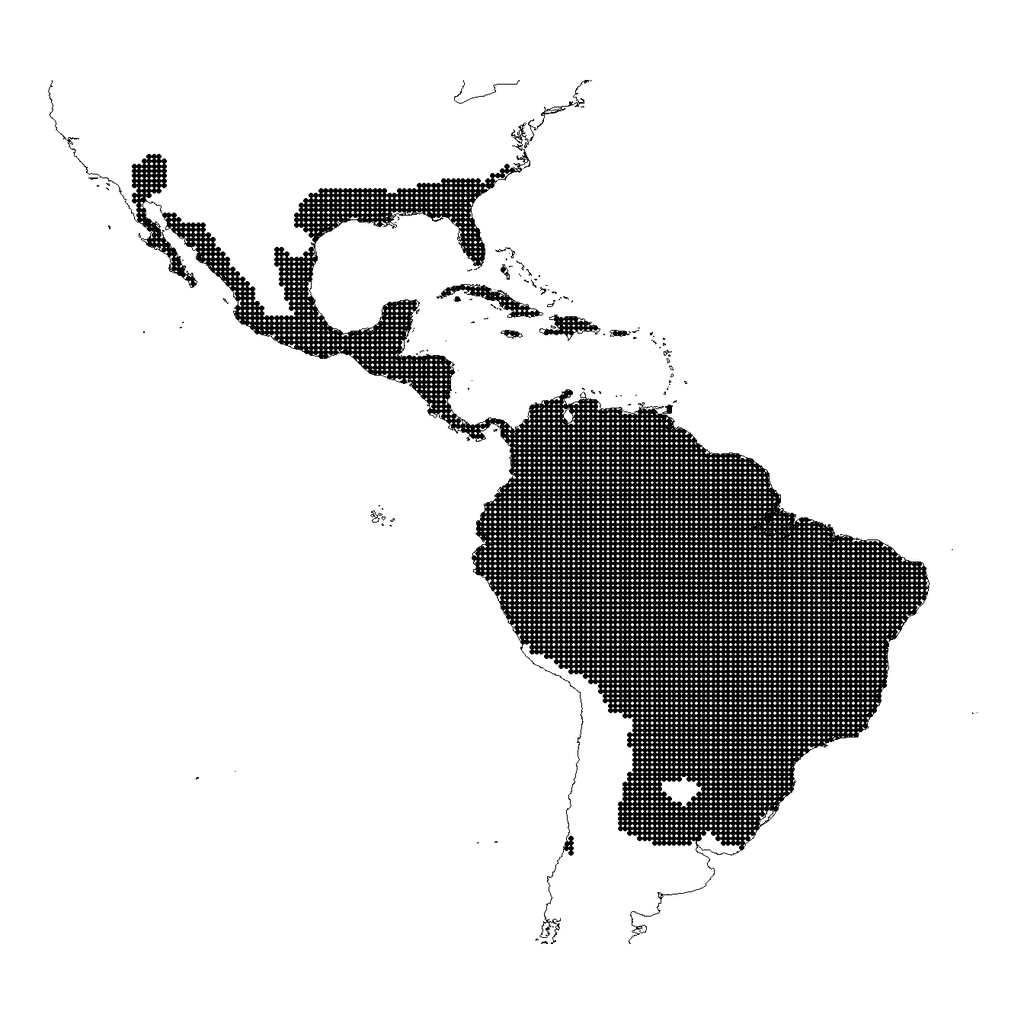

```r
ggplot(grid_centroids) +
  geom_sf(shape=20) +
  geom_sf(data = americas, fill = NA, color = "black") +
  theme_void() + ylim(-40, 40)
```

**Add coordinates to SpatialPolygonsDataframe**

```r
# Add latitude and longitude of grid centroids as extra columns
head(grid)
```

```
## Simple feature collection with 6 features and 3 fields
## Geometry type: MULTIPOLYGON
## Dimension:     XY
## Bounding box:  xmin: -115.0007 ymin: 35.5 xmax: -113.0007 ymax: 36.5
## Geodetic CRS:  +proj=longlat +ellps=WGS84 +no_defs
##   grid_id AREA PORTION                       geometry
## 1     538 0.25     100 MULTIPOLYGON (((-114.0007 3...
## 2     539 0.25     100 MULTIPOLYGON (((-113.5007 3...
## 3     540 0.25     100 MULTIPOLYGON (((-113.0007 3...
## 4     712 0.25     100 MULTIPOLYGON (((-114.5007 3...
## 5     713 0.25     100 MULTIPOLYGON (((-114.0007 3...
## 6     714 0.25     100 MULTIPOLYGON (((-113.5007 3...
```

```r
grid <- cbind(grid, st_coordinates(grid_centroids))
names(grid)[4:5] <- c("longitude", "latitude")
head(grid)
```

```
## Simple feature collection with 6 features and 5 fields
## Geometry type: MULTIPOLYGON
## Dimension:     XY
## Bounding box:  xmin: -115.0007 ymin: 35.5 xmax: -113.0007 ymax: 36.5
## Geodetic CRS:  +proj=longlat +ellps=WGS84 +no_defs
##   grid_id AREA PORTION longitude latitude                       geometry
## 1     538 0.25     100 -114.2507 36.24999 MULTIPOLYGON (((-114.0007 3...
## 2     539 0.25     100 -113.7507 36.24999 MULTIPOLYGON (((-113.5007 3...
## 3     540 0.25     100 -113.2507 36.24999 MULTIPOLYGON (((-113.0007 3...
## 4     712 0.25     100 -114.7507 35.75000 MULTIPOLYGON (((-114.5007 3...
## 5     713 0.25     100 -114.2507 35.75000 MULTIPOLYGON (((-114.0007 3...
## 6     714 0.25     100 -113.7507 35.75000 MULTIPOLYGON (((-113.5007 3...
```

**Make new IDs for neighboring cells**  
Two steps: i) we build an empty matrix with the new IDs, ii) with a `for-loop`, we add the new IDs into the `grid` object.

```r
range(grid$longitude)
```

```
## [1] -115.75066  -35.25066
```

```r
range(grid$latitude)
```

```
## [1] -34.75000  36.24999
```

```r
longitude <- seq(-116, -34, by = 2)
latitude  <- seq(-35, 35, by = 2)

new_ID_matrix <- matrix(c(1:(length(longitude)*length(latitude))),
                        nrow = length(longitude), ncol = length(latitude),
                        dimnames = list(longitude, latitude), byrow = TRUE)
dim(new_ID_matrix)
```

```
## [1] 42 36
```

```r
new_ID_matrix[1:5, 1:5]
```

```
##      -35 -33 -31 -29 -27
## -116   1   2   3   4   5
## -114  37  38  39  40  41
## -112  73  74  75  76  77
## -110 109 110 111 112 113
## -108 145 146 147 148 149
```

```r
# Filling
grid$new_ID <- NA

for(i in 1:nrow(grid)){
  grid$new_ID[i] <- new_ID_matrix[which(longitude < grid$longitude[i] &
                                          (longitude + 2) > grid$longitude[i]),
                                  which(latitude < grid$latitude[i] &
                                          (latitude + 2) > grid$latitude[i])]
}

head(grid)
```

```
## Simple feature collection with 6 features and 6 fields
## Geometry type: MULTIPOLYGON
## Dimension:     XY
## Bounding box:  xmin: -115.0007 ymin: 35.5 xmax: -113.0007 ymax: 36.5
## Geodetic CRS:  +proj=longlat +ellps=WGS84 +no_defs
##   grid_id AREA PORTION longitude latitude                       geometry new_ID
## 1     538 0.25     100 -114.2507 36.24999 MULTIPOLYGON (((-114.0007 3...     36
## 2     539 0.25     100 -113.7507 36.24999 MULTIPOLYGON (((-113.5007 3...     72
## 3     540 0.25     100 -113.2507 36.24999 MULTIPOLYGON (((-113.0007 3...     72
## 4     712 0.25     100 -114.7507 35.75000 MULTIPOLYGON (((-114.5007 3...     36
## 5     713 0.25     100 -114.2507 35.75000 MULTIPOLYGON (((-114.0007 3...     36
## 6     714 0.25     100 -113.7507 35.75000 MULTIPOLYGON (((-113.5007 3...     72
```

**Join neighboring cells based on new IDs & aggregate species distribution data using the new grid**

```r
grid_2degrees <- group_by(grid, new_ID)
grid_2degrees <- summarise(grid_2degrees, do_union = TRUE, is_coverage = TRUE)

head(grid_2degrees)
```

```
## Simple feature collection with 6 features and 1 field
## Geometry type: GEOMETRY
## Dimension:     XY
## Bounding box:  xmin: -116.0007 ymin: 26 xmax: -112.0007 ymax: 36.5
## Geodetic CRS:  +proj=longlat +ellps=WGS84 +no_defs
## # A tibble: 6 × 2
##   new_ID                                                                geometry
##    <int>                                                          <GEOMETRY [°]>
## 1     32 MULTIPOLYGON (((-114.0007 29, -114.5007 29, -114.5007 28.93945, -114.4…
## 2     33 POLYGON ((-114.0007 29.5, -114.0007 29.56253, -114.0336 29.58778, -114…
## 3     34 MULTIPOLYGON (((-114.6508 31.69055, -114.6517 31.69694, -114.6553 31.7…
## 4     35 POLYGON ((-114.0007 33.5, -114.0007 34, -114.0007 34.5, -114.0007 35, …
## 5     36 POLYGON ((-114.0007 35.5, -114.0007 36, -114.0007 36.5, -114.5007 36.5…
## 6     67 POLYGON ((-112.0007 26.5, -112.0007 26.95731, -112.0289 26.99611, -112…
```

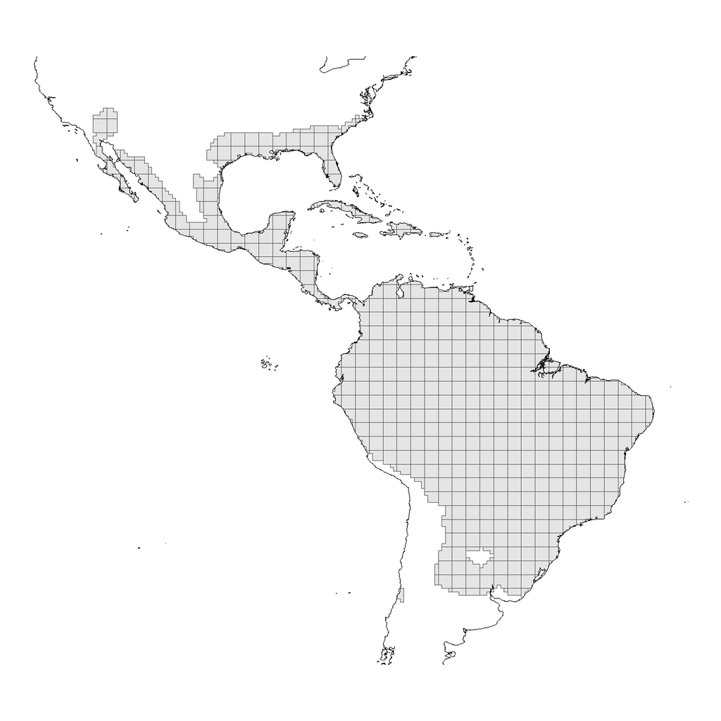

```r
ggplot(grid_2degrees) +
  geom_sf(fill = "gray90") +
  geom_sf(data = americas, fill = NA, color = "black") +
  theme_void() + ylim(-40, 40)
```

```r
# Add new ID also to species data.frame
species <- inner_join(species, st_drop_geometry(grid), by = "grid_id")
head(species)
```

```
##   grid_id spp_Id    GENUS    EPITHET             species    AREA PORTION
## 1   10937    549 Ammandra decasperma Ammandra_decasperma 0.22164  88.656
## 2   10938    549 Ammandra decasperma Ammandra_decasperma 0.25000 100.000
## 3   11112    549 Ammandra decasperma Ammandra_decasperma 0.20082  80.328
## 4   11113    549 Ammandra decasperma Ammandra_decasperma 0.25000 100.000
## 5   11287    549 Ammandra decasperma Ammandra_decasperma 0.16533  66.132
## 6   11288    549 Ammandra decasperma Ammandra_decasperma 0.25000 100.000
##   longitude latitude new_ID
## 1 -77.22738 6.769776    705
## 2 -76.75066 6.750021    705
## 3 -77.20491 6.241400    705
## 4 -76.75066 6.250019    705
## 5 -77.17916 5.725567    705
## 6 -76.75066 5.750018    705
```

# 4. Calculating phylogenetic community metrics

**Prune phylogeny to exclude species not in palm distribution data**  
*Make sure that the same number of species in your data set are in your phylogeny*

```r
palmtree_pruned <- drop.tip(palmtree,
                            palmtree$tip.label[which(!palmtree$tip.label %in% unique(species$species))])
length(palmtree$tip.label)
```

```
## [1] 2539
```

```r
length(palmtree_pruned$tip.label)
```

```
## [1] 506
```

```r
length(unique(species$species))
```

```
## [1] 506
```

```r
write.nexus(palmtree_pruned, file = "data/palmtree_pruned.nex")
```

**Convert long table to species by grid-cell table (a community matrix)**

```r
species <- unique(species[, c("new_ID", "species")])
species_grid <- as.data.frame.matrix(table(species))
species_grid <- as.matrix(species_grid)

dim(species_grid)
```

```
## [1] 479 506
```

```r
species_grid[1:5, 1:5]
```

```
##    Acrocomia_aculeata Acrocomia_hassleri Aiphanes_acaulis
## 32                  0                  0                0
## 33                  0                  0                0
## 34                  0                  0                0
## 35                  0                  0                0
## 36                  0                  0                0
##    Aiphanes_chiribogensis Aiphanes_deltoidea
## 32                      0                  0
## 33                      0                  0
## 34                      0                  0
## 35                      0                  0
## 36                      0                  0
```

```r
write.csv(species_grid, file = "data/palms_specsxsites_phylo.csv")
```

```r
# if you have a hard time reading in the large palm phylogeny or
# in case you got stuck above
palmtree_pruned <- read.nexus("data/palmtree_pruned.nex")
species_grid <- as.matrix(read.csv("data/palms_specsxsites_phylo.csv", row.names = 1))
```

**Calculate phylogenetic diversity**

We here calculate the Faith’s PD (phylogenetic diversity index), which can be written like this:
$$PD = \sum_{branches}l(b)$$
with $l$ the length of a branch $b$.

```r
# ?pd
pd_palms <- pd(species_grid, palmtree_pruned)
dim(pd_palms) # one value per grid cell
```

```
## [1] 479   2
```

```r
head(pd_palms)
```

```
##          PD SR
## 32 140.0006  2
## 33 140.0006  2
## 34 104.6140  1
## 35 104.6140  1
## 36 104.6140  1
## 67 140.0006  2
```

```r
# Adding the ID of grid cells
pd_palms <- data.frame(new_ID = as.integer(row.names(species_grid)), pd_palms)
head(pd_palms)
```

```
##    new_ID       PD SR
## 32     32 140.0006  2
## 33     33 140.0006  2
## 34     34 104.6140  1
## 35     35 104.6140  1
## 36     36 104.6140  1
## 67     67 140.0006  2
```

`pd()` calculates Faith’s PD and a corrected version of it being the residuals of a regression with total abundance or species richness per plot. Let’s look into this:

```r
pd_model <- lm(PD ~ SR, data = pd_palms)
pd_palms$residuals <- residuals(pd_model)
head(pd_palms)
```

```
##    new_ID       PD SR  residuals
## 32     32 140.0006  2  -90.78048
## 33     33 140.0006  2  -90.78048
## 34     34 104.6140  1 -105.49840
## 35     35 104.6140  1 -105.49840
## 36     36 104.6140  1 -105.49840
## 67     67 140.0006  2  -90.78048
```

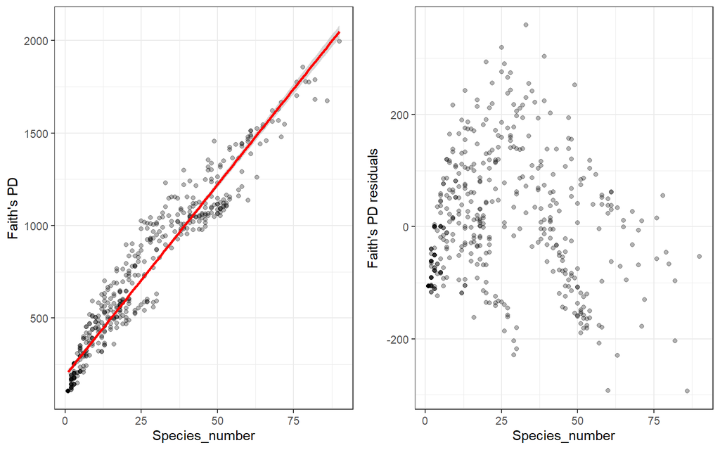

```r
plot_grid(nrow = 1, ncol = 2,
          ggplot(pd_palms, aes(SR, PD)) +
            geom_point(color = "black", alpha = 0.3) +
            stat_smooth(method = "lm", formula = y ~ x, color = "red") +
            labs(x = "Species_number", y = "Faith's PD") +
            theme_bw(),
          ggplot(pd_palms, aes(SR, residuals)) +
            geom_point(color = "black", alpha = 0.3) +
            labs(x = "Species_number", y = "Faith's PD residuals") +
            theme_bw())
```

**Calculate generic phylogenetic metrics (absolute and standardized)**

Phylogenetic diversity metrics are standardized by first using a null model to generate expected values.  
The principle of null models is illustrated in the following figure:

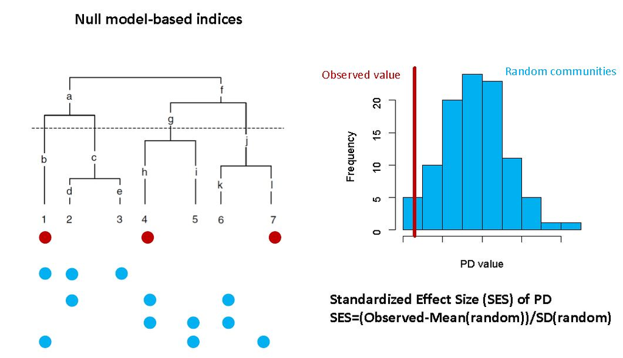

Then, the observed value is compared to the null, usually using standardized effect sizes (SES):
$$SES =
(observed - mean.null)/sd.null$$
where *mean.null* is the mean of the null values and *sd.null* is the standard deviation of the null values.

Null models can also apply to other phylogenetic diversity indices like the Mean Pairwise Distance (MPD) and the Mean Nearest Taxon Distance (MNTD).

MPD consists in calculating all the pairwise distances between species in a grid cell and then takes the mean.  
MNTD calculates the mean distance separating each species in the grid cell from its closest relative. These indices are described in Webb el al. (2002).

```r
c.data <- comparative.comm(palmtree_pruned , species_grid)
pd.null <- generic.null(c.data, c(.pd, .mpd, .mntd), null.model = "richness",
                        comp.fun = .ses, permute = 100)
colnames(pd.null) <- c("Faith_PD", "Corrected_FaithPD", "MPD", "MNTD")
rownames(pd.null) <- sites(c.data)
pd.null <- data.frame(pd.null)
pd.null$new_ID <- as.numeric(rownames(pd.null))

dim(pd.null); head(pd.null)
```

```
## [1] 479  21
```

```
##      Faith_PD.observed Corrected_FaithPD.observed MPD.observed MNTD.observed
## 1009          104.6140               -105.6068852           NA            NA
## 1010          190.8985                -40.0233588     172.5688     172.56882
## 1011          212.9137                -38.7090180     129.7227      86.87658
## 1012          160.0228                -70.8990407     110.8175     110.81746
## 1013          252.0204                  0.3977046     155.7938     139.01887
## 1014          329.4444                 36.4198899     142.3322      88.67323
##      Faith_PD.null.mean Corrected_FaithPD.null.mean MPD.null.mean
## 1009           104.6140                  -170.71852            NA
## 1010           171.3024                  -128.42072      133.3768
## 1011           230.9088                   -93.20494      134.8838
## 1012           172.7410                  -126.98217      136.2539
## 1013           231.3479                   -92.76588      135.2566
## 1014           337.0333                   -35.86164      138.1383
##      MNTD.null.mean  Faith_PD.SE Corrected_FaithPD.SE   MPD.SE  MNTD.SE
```

[output cut: 20 more lines]

```r
# select columns of interest for final data set
pd.out <- pd.null[, c("new_ID", "Faith_PD.observed", "Faith_PD.SES",
                      "MPD.observed", "MPD.SES", "MNTD.observed", "MNTD.SES")]
head(pd.out)
```

```
##      new_ID Faith_PD.observed Faith_PD.SES MPD.observed   MPD.SES MNTD.observed
## 1009   1009          104.6140    -5.350016           NA        NA            NA
## 1010   1010          190.8985     9.174118     172.5688  9.174118     172.56882
## 1011   1011          212.9137    -6.219039     129.7227 -1.967896      86.87658
## 1012   1012          160.0228    -6.013927     110.8175 -6.013927     110.81746
## 1013   1013          252.0204     5.844392     155.7938  6.349723     139.01887
## 1014   1014          329.4444    -1.676467     142.3322  2.247913      88.67323
##       MNTD.SES
## 1009        NA
## 1010  9.174118
## 1011 -9.467532
## 1012 -6.013927
## 1013  5.290071
## 1014 -3.670299
```

```r
# change NAs to zeroes; zero phylogenetic diversity if grid has only 1 spp!
pd.out[is.na(pd.out)] <- 0

head(pd.out)
```

```
##      new_ID Faith_PD.observed Faith_PD.SES MPD.observed   MPD.SES MNTD.observed
## 1009   1009          104.6140    -5.350016       0.0000  0.000000       0.00000
## 1010   1010          190.8985     9.174118     172.5688  9.174118     172.56882
## 1011   1011          212.9137    -6.219039     129.7227 -1.967896      86.87658
## 1012   1012          160.0228    -6.013927     110.8175 -6.013927     110.81746
## 1013   1013          252.0204     5.844392     155.7938  6.349723     139.01887
## 1014   1014          329.4444    -1.676467     142.3322  2.247913      88.67323
##       MNTD.SES
## 1009  0.000000
## 1010  9.174118
## 1011 -9.467532
## 1012 -6.013927
## 1013  5.290071
## 1014 -3.670299
```

```r
head(pd_palms)
```

```
##    new_ID       PD SR  residuals
## 32     32 140.0006  2  -90.78048
## 33     33 140.0006  2  -90.78048
## 34     34 104.6140  1 -105.49840
## 35     35 104.6140  1 -105.49840
## 36     36 104.6140  1 -105.49840
## 67     67 140.0006  2  -90.78048
```

```r
palmdiversity <- left_join(pd_palms, pd.out, by = "new_ID")
head(palmdiversity)
```

```
##   new_ID       PD SR  residuals Faith_PD.observed Faith_PD.SES MPD.observed
## 1     32 140.0006  2  -90.78048          140.0006    -14.55384      70.7732
## 2     33 140.0006  2  -90.78048          140.0006    -17.79373      70.7732
## 3     34 104.6140  1 -105.49840          104.6140    -17.74630       0.0000
## 4     35 104.6140  1 -105.49840          104.6140    -14.51689       0.0000
## 5     36 104.6140  1 -105.49840          104.6140    -16.74262       0.0000
## 6     67 140.0006  2  -90.78048          140.0006    -17.28294      70.7732
##     MPD.SES MNTD.observed  MNTD.SES
## 1 -14.55384       70.7732 -14.55384
## 2 -17.79373       70.7732 -17.79373
## 3   0.00000        0.0000   0.00000
## 4   0.00000        0.0000   0.00000
## 5   0.00000        0.0000   0.00000
## 6 -17.28294       70.7732 -17.28294
```

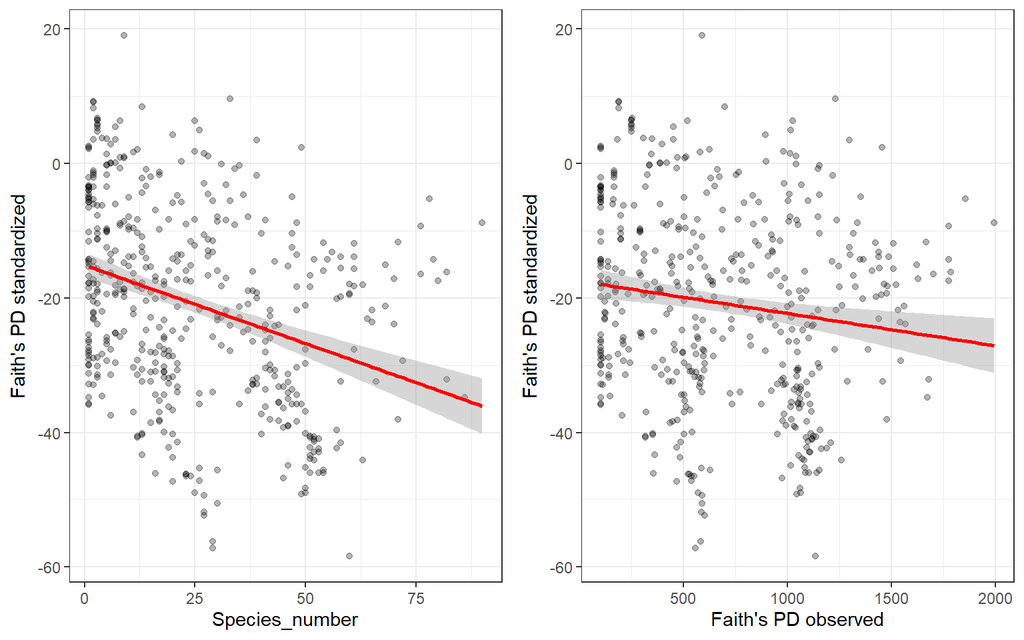

```r
# Plot
plot_grid(nrow = 1, ncol = 2,
          ggplot(palmdiversity, aes(SR, Faith_PD.SES)) +
            geom_point(color = "black", alpha = 0.3) +
            stat_smooth(method = "lm", formula = y ~ x, color = "red") +
            labs(x = "Species_number", y = "Faith's PD standardized") +
            theme_bw(),
          ggplot(palmdiversity, aes(Faith_PD.observed, Faith_PD.SES)) +
            geom_point(color = "black", alpha = 0.3) +
            stat_smooth(method = "lm", formula = y ~ x, color = "red") +
            labs(x = "Faith's PD observed", y = "Faith's PD standardized") +
            theme_bw())
```

## a. Exercise II

**Tasks**:  
1. Plot correlations among the diversity metrics in the palm diversity data.frame (use `ggpairs()`).  
2. Join the `palmdiversity` data.frame to the grid_2degrees shapefile to be able to link the diversity metrics and the poylgons for plotting.  
3. Plot maps with colours according to the diversity metrics.

**Exercise II solutions:**

*Plot correlations among the diversity metrics*

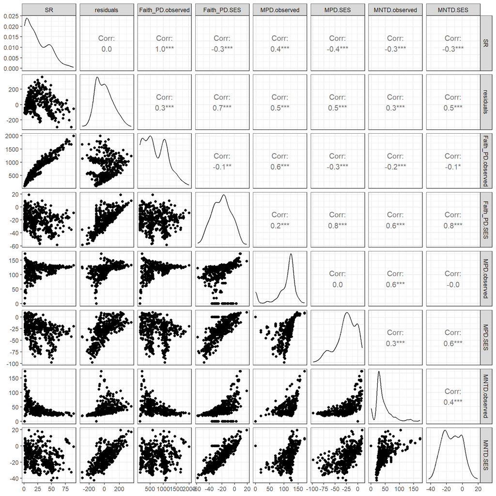

*Join the palmdiversity data.frame to the shapefile with the new gridcell IDs*

```
## Simple feature collection with 6 features and 1 field
## Geometry type: GEOMETRY
## Dimension:     XY
## Bounding box:  xmin: -116.0007 ymin: 26 xmax: -112.0007 ymax: 36.5
## Geodetic CRS:  +proj=longlat +ellps=WGS84 +no_defs
## # A tibble: 6 × 2
##   new_ID                                                                geometry
##    <int>                                                          <GEOMETRY [°]>
## 1     32 MULTIPOLYGON (((-114.0007 29, -114.5007 29, -114.5007 28.93945, -114.4…
## 2     33 POLYGON ((-114.0007 29.5, -114.0007 29.56253, -114.0336 29.58778, -114…
## 3     34 MULTIPOLYGON (((-114.6508 31.69055, -114.6517 31.69694, -114.6553 31.7…
## 4     35 POLYGON ((-114.0007 33.5, -114.0007 34, -114.0007 34.5, -114.0007 35, …
## 5     36 POLYGON ((-114.0007 35.5, -114.0007 36, -114.0007 36.5, -114.5007 36.5…
## 6     67 POLYGON ((-112.0007 26.5, -112.0007 26.95731, -112.0289 26.99611, -112…
```

```
##   new_ID       PD SR  residuals Faith_PD.observed Faith_PD.SES MPD.observed
## 1     32 140.0006  2  -90.78048          140.0006    -14.55384      70.7732
## 2     33 140.0006  2  -90.78048          140.0006    -17.79373      70.7732
## 3     34 104.6140  1 -105.49840          104.6140    -17.74630       0.0000
## 4     35 104.6140  1 -105.49840          104.6140    -14.51689       0.0000
## 5     36 104.6140  1 -105.49840          104.6140    -16.74262       0.0000
## 6     67 140.0006  2  -90.78048          140.0006    -17.28294      70.7732
##     MPD.SES MNTD.observed  MNTD.SES
## 1 -14.55384       70.7732 -14.55384
## 2 -17.79373       70.7732 -17.79373
## 3   0.00000        0.0000   0.00000
## 4   0.00000        0.0000   0.00000
## 5   0.00000        0.0000   0.00000
## 6 -17.28294       70.7732 -17.28294
```

```
## Simple feature collection with 6 features and 10 fields
## Geometry type: GEOMETRY
## Dimension:     XY
## Bounding box:  xmin: -116.0007 ymin: 26 xmax: -112.0007 ymax: 36.5
## Geodetic CRS:  +proj=longlat +ellps=WGS84 +no_defs
## # A tibble: 6 × 11
##   new_ID                        geometry    PD    SR residuals Faith_PD.observed
##    <dbl>                  <GEOMETRY [°]> <dbl> <dbl>     <dbl>             <dbl>
## 1     32 MULTIPOLYGON (((-114.0007 29, …  140.     2     -90.8              140.
## 2     33 POLYGON ((-114.0007 29.5, -114…  140.     2     -90.8              140.
## 3     34 MULTIPOLYGON (((-114.6508 31.6…  105.     1    -105.               105.
## 4     35 POLYGON ((-114.0007 33.5, -114…  105.     1    -105.               105.
## 5     36 POLYGON ((-114.0007 35.5, -114…  105.     1    -105.               105.
## 6     67 POLYGON ((-112.0007 26.5, -112…  140.     2     -90.8              140.
## # ℹ 5 more variables: Faith_PD.SES <dbl>, MPD.observed <dbl>, MPD.SES <dbl>,
## #   MNTD.observed <dbl>, MNTD.SES <dbl>
```

*Plot maps with different colours for each diversity metric*

*Species richness, PD, MPD & MNTD (absolute)*

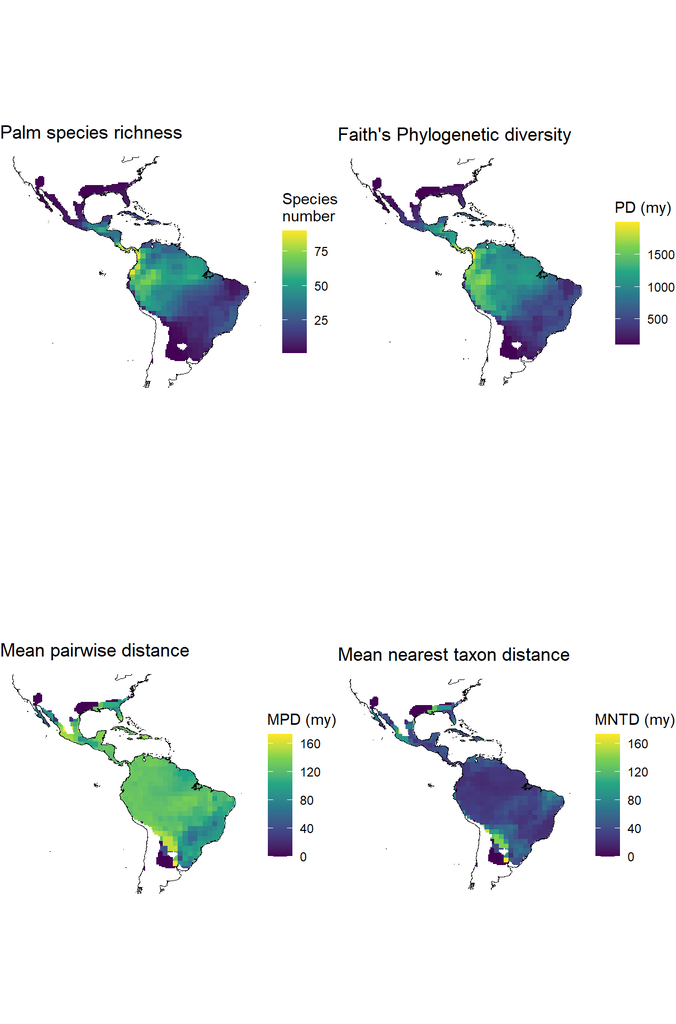

*PD, MPD & MNTD (standardized)*

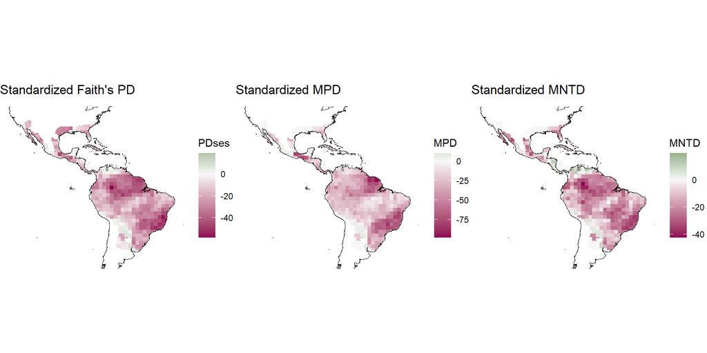

# References

[Faurby S, Eiserhardt WL, Baker WJ, Svenning JC. An all-evidence species-level supertree for the palms (Arecaceae). Mol Phylogenet Evol. 2016 Jul;100:57-69.](https://doi.org/10.1016/j.ympev.2016.03.002)

Faith D.P. (1992) Conservation evaluation and phylogenetic diversity. Biological Conservation, 61, 1-10

[Kreft, H., Sommer, J.H. and Barthlott, W. (2006), The significance of geographic range size for spatial diversity patterns in Neotropical palms. Ecography, 29: 21-30.](https://doi.org/10.1111/j.2005.0906-7590.04203.x)

[World Checklist of Vascular Plants](https://powo.science.kew.org/)

[Phylogenies and Community Ecology Campbell O. Webb, David D. Ackerly, Mark A. McPeek, Michael J. Donoghue Annual Review of Ecology and Systematics 2002 33:1, 475-505](https://www.annualreviews.org/doi/abs/10.1146/annurev.ecolsys.33.010802.150448)